# Carbohydrate analysis

AS Huffmyer

2022

This script analyzes and plots data for Symbiotic Integration 2021 carbohydrate data.

# **Setup**

Load libraries.

```r
library(dplyr)
library(readr)
library(stringr)
library(gridExtra)
```

```r
library(grid)
library(ggplot2)
library(lattice)
library(Rmisc)
library(ggpubr)
library(lsmeans)
library(tidyverse)
```

# **Load data**

Read in datafiles

```r
data <- read.csv("Mcap2021/Data/Carbohydrates/20220406_Carbohydrates_data.csv")
Meta <- read.csv("Mcap2021/Data/Carbohydrates/20220406_Carb_Meta.csv")
volumes <- read.csv("Mcap2021/Data/Resuspension_volumes.csv")
```

# **Run with only Initial Standard curve**

Merging Files and renaming columns

```r
data.1 <- merge(Meta, data, by = c("Well", "Run"))
data.1 <- left_join(data.1, volumes, by=c("Tube.ID"))

# Blank correction for each run separately

Blank <- data.1 %>%
  filter(Sample.Type == "Blank") %>%
  filter(Run=="Initial")%>%
  summarise(blk.avg = mean(X485))

data.1$abs.corr <- data.1$X485 - Blank$blk.avg
```

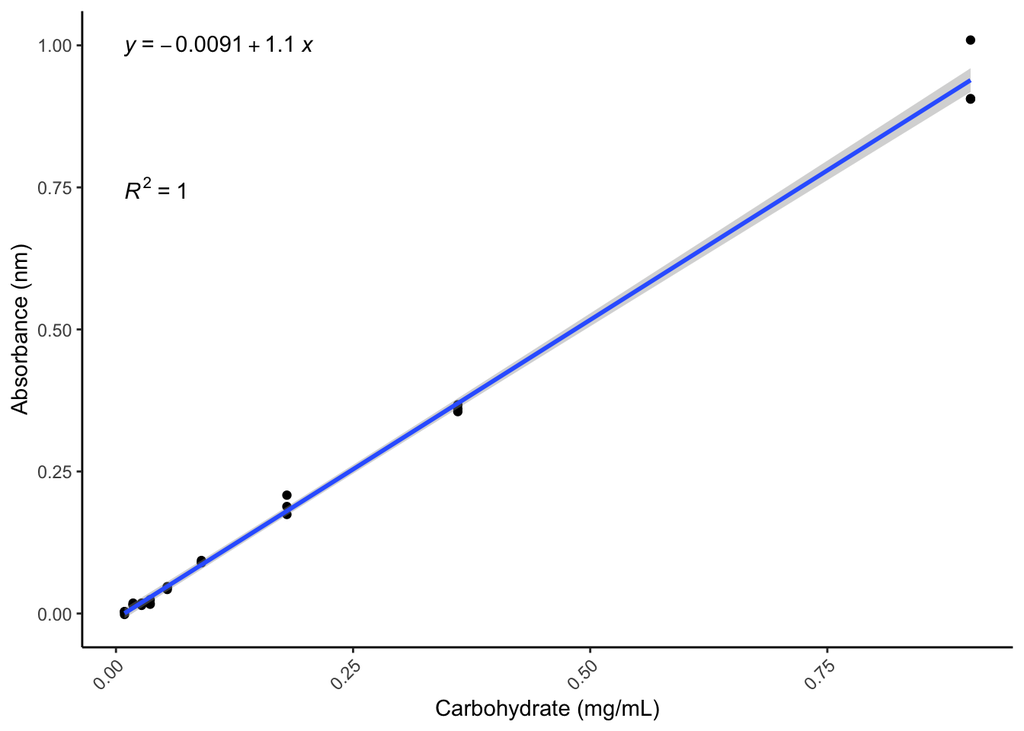

```r
# Standard curve

Standard <- data.1 %>%
  filter(Sample.Type == "Standard")%>%
  filter(Run=="Initial")

Standard.plot <- ggplot(data = Standard, aes(x=Concentration, y=abs.corr))+
  #facet_grid(~Run)+
  ylab("Absorbance (nm)")+ xlab("Carbohydrate (mg/mL)") +
  geom_point()+
  geom_smooth(method = "lm") +
  stat_regline_equation(label.y = 1.0, aes(label = ..eq.label..)) +
  stat_regline_equation(label.y = 0.75, aes(label = ..rr.label..)) +
  theme_bw() + theme(panel.border = element_blank(), panel.grid.major = element_blank(),
                     panel.grid.minor = element_blank(), axis.line = element_line(colour = "black")) +
  theme(axis.text.x = element_text(angle = 45, hjust = 1));Standard.plot
```

Extract standard curve.

```r
lmstandard <- lm (Concentration ~ abs.corr, data = Standard)
lmsummary <- summary(lmstandard)
```

# **Calculations (initial curve)**

Obtain concentration values for samples from standard curve.

```r
Samples <- data.1 %>% #subsetting Samples
  filter(Sample.Type == "Sample")%>%
  filter(!Run=="Initial")

Samples$Concentration <- predict(lmstandard, newdata = Samples) #using model to get concentration
```

Multiply sample concentration (mg/mL) by total slurry volume (mL) and dilution factor (1000/v of sample, usually 100 mL)

```r
Samples$Carb.mg <- (Samples$Concentration * (Samples$Resuspension_volume/1000) * (1000/Samples$Homo_vol))

#Concentration = mg/mL
#Dilution factor 1000/10 for regular protocol doing 900:100 DI:sample
#For us we have 925:75 or 1000/25

#the second term here needs to be the total amount in the host or holobiont tube that we pulled from
#needs to be VOLUME from this page: https://docs.google.com/spreadsheets/d/1kE8Yamrzdh5VDtieGuJGIl37WnuAOXeknBqTraglg3k/edit#gid=316770111
#can call resuspension volume
#need to get these values from Jill

#then the third term is our "input" volume (called Homo_vol here)
```

Carbohydrates are now in total mg carbohydrates in each sample.

Plot by individual sample

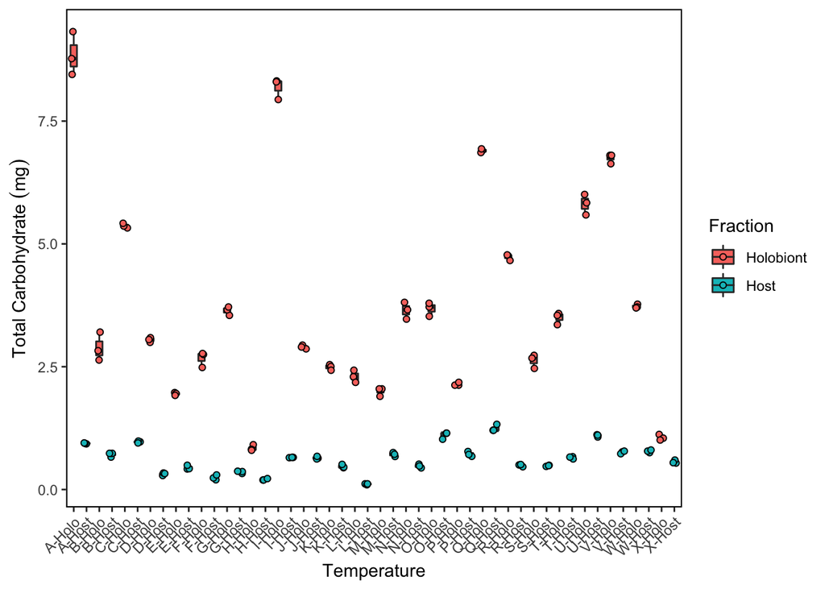

```r
Carb.Plot.samples <- Samples%>%
  filter(!Treatment=="Astrangia")%>%
  ggplot(aes(x=Tube.ID, y=Carb.mg, fill = Fraction)) +
  geom_boxplot(width=.5, outlier.shape= NA, position = position_dodge(width = 0.4)) +
   #scale_fill_manual(values=c("blue", "red"))+
#  stat_summary(fun=mean, aes(group=Fraction, color = Fraction), position = position_dodge(width = 0.5))  +
  geom_point(pch = 21, position=position_jitterdodge(dodge.width=0.4)) +
  #  ylim(0,0.5) +
  #geom_text(position=position_jitterdodge(dodge.width=0.4))+
  xlab("Temperature") + ylab(expression("Total Carbohydrate " (mg))) + #Axis titles
  theme_bw() + theme(panel.border = element_rect(color="black", fill=NA, size=0.75), panel.grid.major = element_blank(), #Makes background theme white
                     panel.grid.minor = element_blank(), axis.line = element_blank()) +
  #  theme(axis.text = element_text(size = 30, color = "black"),
  #        axis.title = element_text(size = 36, color = "black")) +
  theme(axis.text.x = element_text(angle = 45, hjust = 1)); Carb.Plot.samples
```

We need to remove H, since it was a very dilute sample.

Plot only larvae

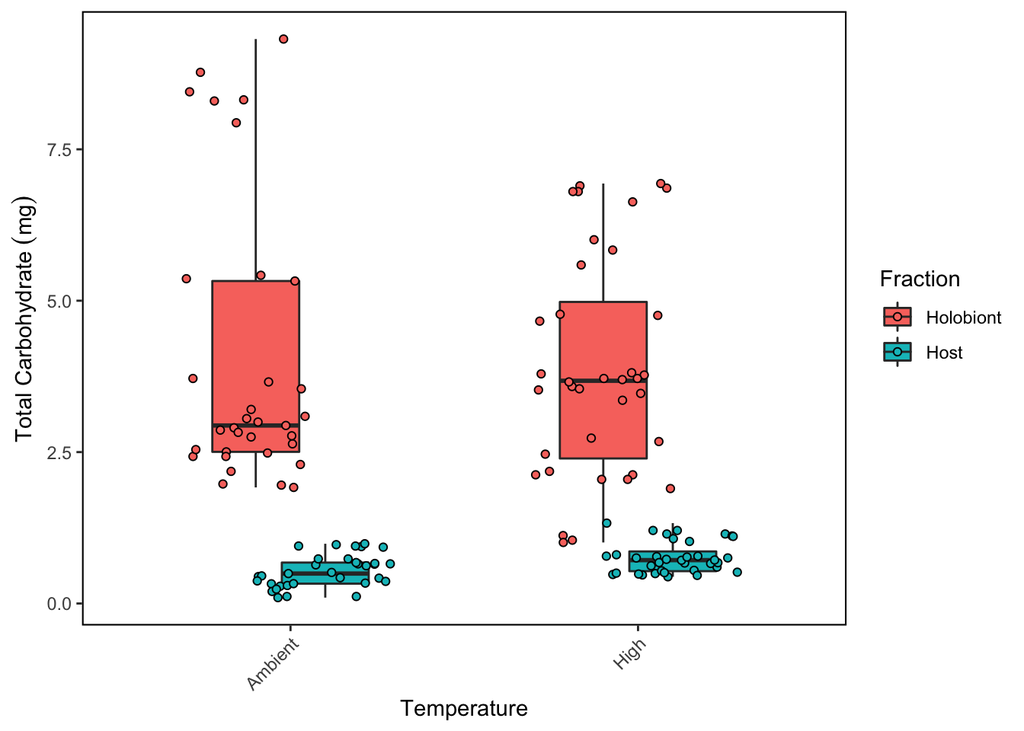

```r
Carb.Plot <- Samples%>%
  filter(!Treatment=="Astrangia")%>%
  filter(!Sample.ID=="H")%>%
  ggplot(aes(x=Treatment, y=Carb.mg, fill = Fraction)) +
  geom_boxplot(width=.5, outlier.shape= NA, position = position_dodge(width = 0.4)) +
  geom_point(pch = 21, position=position_jitterdodge(dodge.width=0.4)) +
  xlab("Temperature") + ylab(expression("Total Carbohydrate " (mg))) + #Axis titles
  theme_bw() + theme(panel.border = element_rect(color="black", fill=NA, size=0.75), panel.grid.major = element_blank(),
                     panel.grid.minor = element_blank(), axis.line = element_blank()) +
  theme(axis.text.x = element_text(angle = 45, hjust = 1)); Carb.Plot
```

Test for differences with an anova.

```r
model<-Samples%>%
  filter(!Treatment=="Astrangia")%>%
  filter(!Sample.ID=="H")%>%

  aov(Carb.mg~Treatment*Fraction, data=.)

summary(model)
```

```
##                     Df Sum Sq Mean Sq F value Pr(>F)
## Treatment            1    0.1     0.1   0.024  0.876
## Fraction             1  375.7   375.7 172.051 <2e-16 ***
## Treatment:Fraction   1    1.2     1.2   0.544  0.462
## Residuals          134  292.6     2.2
## ---
## Signif. codes:  0 '***' 0.001 '**' 0.01 '*' 0.05 '.' 0.1 ' ' 1
```

Potential outliers are A, I (high values), and H (low values). H will be removed.

# **Run with all runs Standard curve**

Merging Files and renaming columns

```r
data.1.all <- merge(Meta, data, by = c("Well", "Run"))
data.1.all <- left_join(data.1.all, volumes, by=c("Tube.ID"))

# Blank correction for each run separately

Blank.all <- data.1.all %>%
  filter(Sample.Type == "Blank") %>%
  #filter(Run=="Initial")%>%
  summarise(blk.avg = mean(X485))

data.1.all$abs.corr <- data.1.all$X485 - Blank.all$blk.avg
```

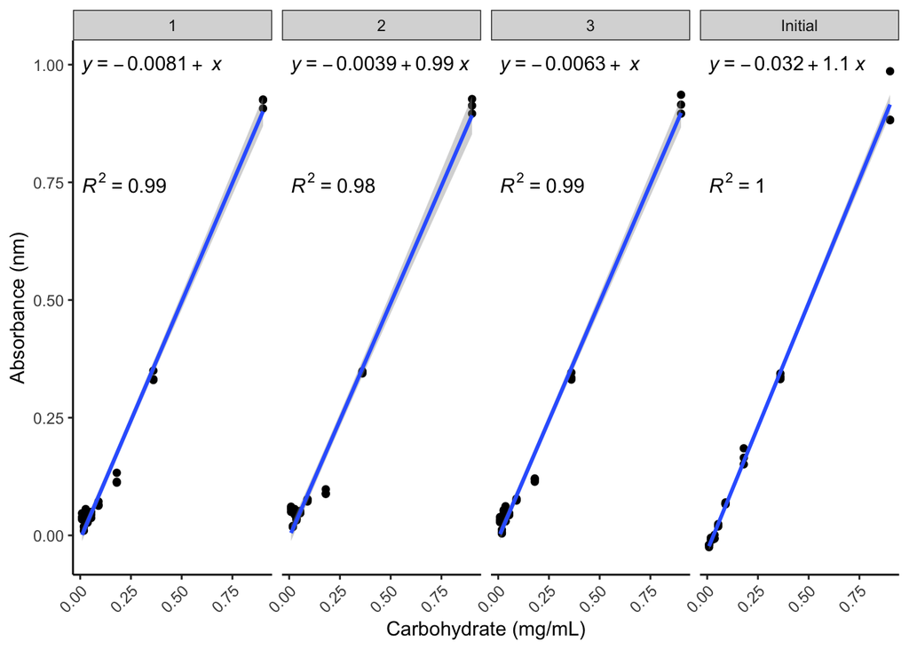

```r
# Standard curve

Standard.all <- data.1.all %>%
  filter(Sample.Type == "Standard") #%>%
  #filter(Run=="Initial")

Standard.plot.all <- ggplot(data = Standard.all, aes(x=Concentration, y=abs.corr))+
  facet_grid(~Run)+
  ylab("Absorbance (nm)")+ xlab("Carbohydrate (mg/mL)") +
  geom_point()+
  geom_smooth(method = "lm") +
  stat_regline_equation(label.y = 1.0, aes(label = ..eq.label..)) +
  stat_regline_equation(label.y = 0.75, aes(label = ..rr.label..)) +
  theme_bw() + theme(panel.border = element_blank(), panel.grid.major = element_blank(),
                     panel.grid.minor = element_blank(), axis.line = element_line(colour = "black")) +
  theme(axis.text.x = element_text(angle = 45, hjust = 1));Standard.plot.all
```

Extract standard curve.

```r
lmstandard.all <- lm (Concentration ~ abs.corr, data = Standard.all)
lmsummary.all <- summary(lmstandard.all)
```

# **Calculations (using all curves combined)**

Obtain concentration values for samples from standard curve.

```r
Samples.all <- data.1.all %>% #subsetting Samples
  filter(Sample.Type == "Sample")%>%
  filter(!Run=="Initial")

Samples.all$Concentration <- predict(lmstandard.all, newdata = Samples.all) #using model to get concentration
```

Accounting for dilution factor (1000/10) and normalizing to homogenate volume

```r
Samples.all$Carb.mg <- (Samples.all$Concentration * (Samples.all$Resuspension_volume/1000) * (1000/Samples.all$Homo_vol))

#Concentration = mg/mL
#Dilution factor 1000/10 for regular protocol doing 900:100 DI:sample
#For us we have 925:75 or 1000/25

#the second term here needs to be the total amount in the host or holobiont tube that we pulled from
#needs to be VOLUME from this page: https://docs.google.com/spreadsheets/d/1kE8Yamrzdh5VDtieGuJGIl37WnuAOXeknBqTraglg3k/edit#gid=316770111
#can call resuspension volume

#then the third term is our "input" volume (called Homo_vol here)
```

Plot only larvae

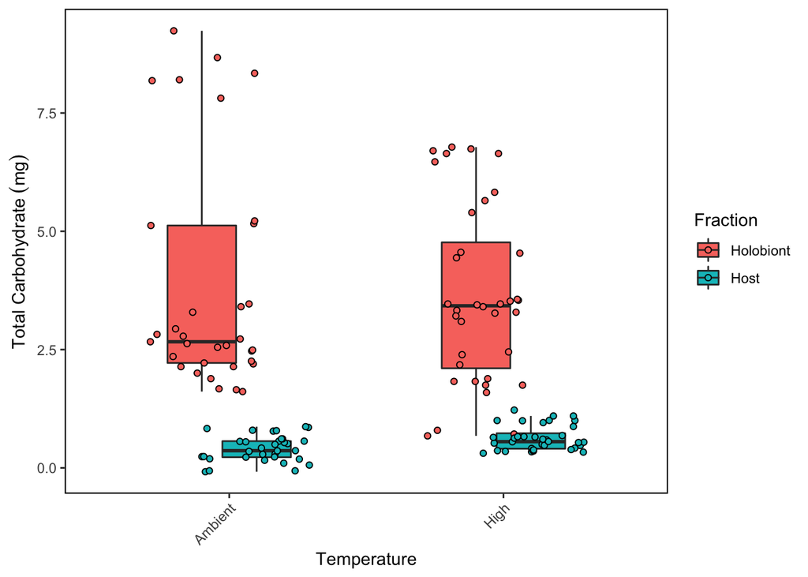

```r
Carb.Plot.all <- Samples.all%>%
  filter(!Sample.ID=="H")%>%
  filter(!Treatment=="Astrangia")%>%
  ggplot(aes(x=Treatment, y=Carb.mg, fill = Fraction)) +
  geom_boxplot(width=.5, outlier.shape= NA, position = position_dodge(width = 0.4)) +
  geom_point(pch = 21, position=position_jitterdodge(dodge.width=0.4)) +
  xlab("Temperature") + ylab(expression("Total Carbohydrate " (mg))) + #Axis titles
  theme_bw() + theme(panel.border = element_rect(color="black", fill=NA, size=0.75), panel.grid.major = element_blank(),
                     panel.grid.minor = element_blank(), axis.line = element_blank()) +
  theme(axis.text.x = element_text(angle = 45, hjust = 1)); Carb.Plot.all
```

Potential outliers are A, I (high values), and H (low values)

# **Show plots side by side**

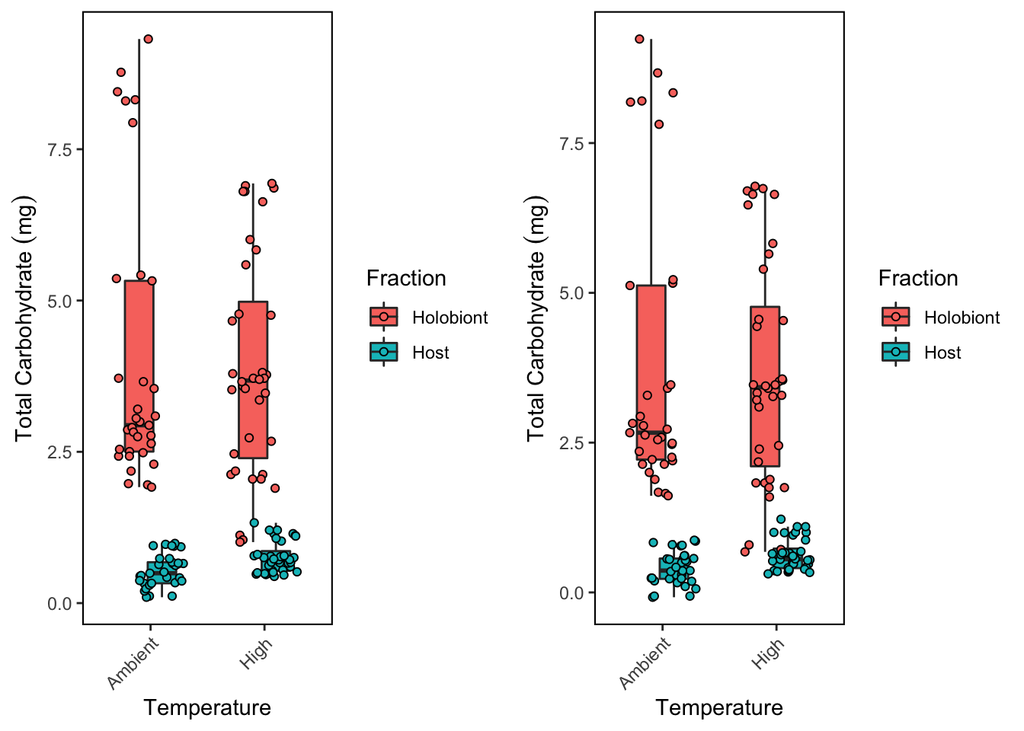

```r
library(cowplot)
larvae.compare<-plot_grid(Carb.Plot, Carb.Plot.all, nrow=1, ncol=2)
larvae.compare
```

We get the same answer with very minor differences using the curves. So we will proceed with using the first curve (Initial Run) because it was more robust.

# **Calculate Ratio of host:holobiont**

Calculate the ratio of host:holobiont carbohydrates

Calculate the average host and average holobiont signal for each sample.

```r
ratios<-Samples%>%
  filter(!Treatment=="Astrangia")%>%
  filter(!Sample.ID=="H")%>%
  dplyr::select(Sample.ID, Treatment, Fraction, Carb.mg)%>%
  group_by(Sample.ID, Fraction, Treatment)%>%
  dplyr::summarise(mean_carbs=mean(Carb.mg))%>%
  spread(Fraction, mean_carbs)%>%
  mutate(ratio=Host/Holobiont)
```

Plot Host:Holobiont ratios

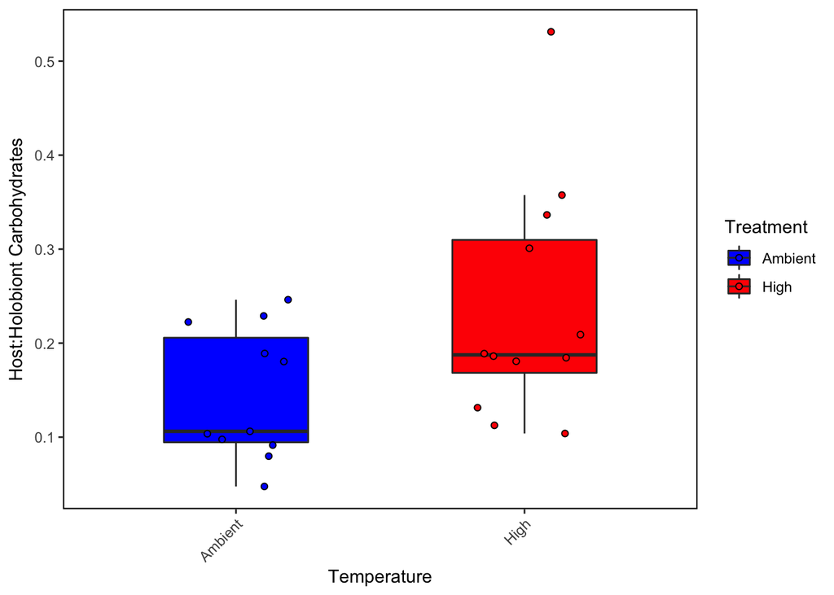

```r
Ratio.Plot <- ratios%>%
  ggplot(aes(x=Treatment, y=ratio, fill=Treatment)) +
  geom_boxplot(width=.5, outlier.shape= NA, position = position_dodge(width = 0.4)) +
  geom_point(pch = 21, position=position_jitterdodge(dodge.width=0.4)) +
   scale_fill_manual(values=c("blue", "red"))+
  xlab("Temperature") + ylab(expression("Host:Holobiont Carbohydrates")) + #Axis titles
  theme_bw() + theme(panel.border = element_rect(color="black", fill=NA, size=0.75), panel.grid.major = element_blank(),
                     panel.grid.minor = element_blank(), axis.line = element_blank()) +
  theme(axis.text.x = element_text(angle = 45, hjust = 1)); Ratio.Plot
```

Test for differences with an anova.

```r
model<-aov(ratio~Treatment, data=ratios)
summary(model)
```

```
##             Df  Sum Sq Mean Sq F value Pr(>F)
## Treatment    1 0.04691 0.04691   4.487 0.0462 *
## Residuals   21 0.21956 0.01046
## ---
## Signif. codes:  0 '***' 0.001 '**' 0.01 '*' 0.05 '.' 0.1 ' ' 1
```

There is a significant difference in Host:Holobiont ratios of carbohydrates at high temperature.

# **Normalize to protein values**

Read in protein values (total protein per sample in ug).

```r
protein<-read.csv("Mcap2021/Output/Protein/protein_output.csv")
```

Merge data frames.

```r
Samples_norm<-Samples%>%
  filter(!Treatment=="Astrangia")%>%
  filter(!Sample.ID=="H")%>%
  dplyr::group_by(Tube.ID, Sample.ID, Treatment)%>%
  dplyr::summarise(Carb.mg=mean(Carb.mg))
Samples_norm<-left_join(Samples_norm, protein)
```

Convert carbs from mg to ug (multiply by 1000). Normalize carbs (ug) to protein (ug) to obtain carbs per unit protein.

```r
Samples_norm<-Samples_norm%>%
  mutate(Carb.ug=Carb.mg*1000)%>%
  mutate(Carb.normalized=Carb.ug/Protein.ug)
```

Plot.

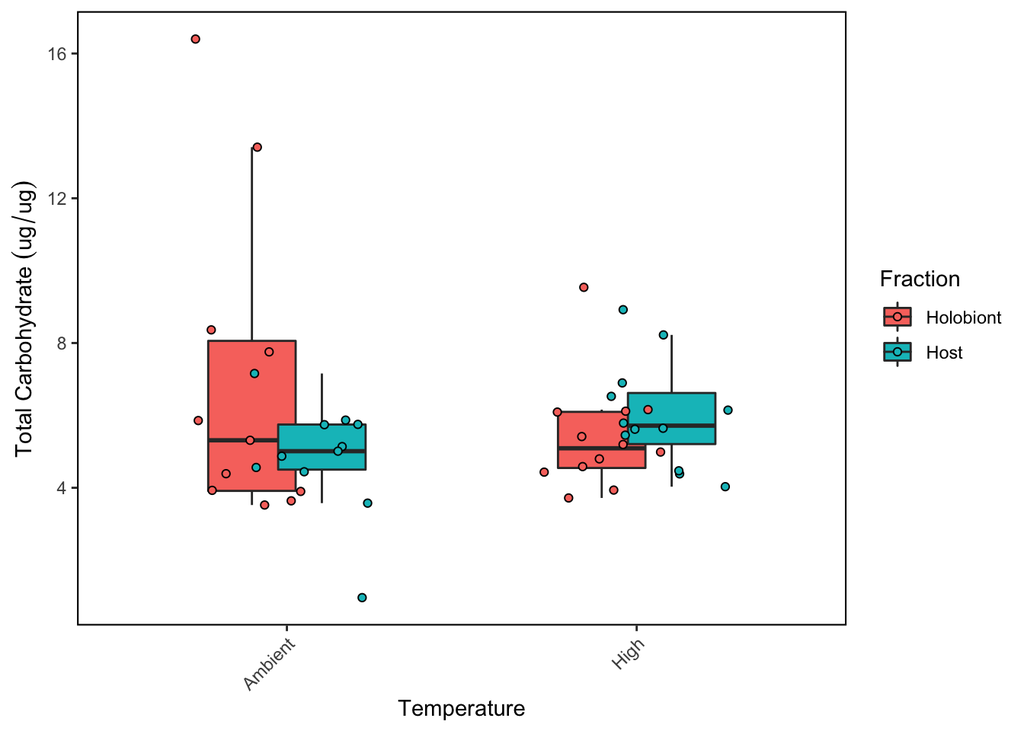

```r
Carb.Plot.norm <- Samples_norm%>%
  ggplot(aes(x=Treatment, y=Carb.normalized, fill = Fraction)) +
  geom_boxplot(width=.5, outlier.shape= NA, position = position_dodge(width = 0.4)) +
  geom_point(pch = 21, position=position_jitterdodge(dodge.width=0.4)) +
  xlab("Temperature") + ylab(expression("Total Carbohydrate " (ug/ug))) + #Axis titles
  theme_bw() + theme(panel.border = element_rect(color="black", fill=NA, size=0.75), panel.grid.major = element_blank(),
                     panel.grid.minor = element_blank(), axis.line = element_blank()) +
  theme(axis.text.x = element_text(angle = 45, hjust = 1)); Carb.Plot.norm
```

Test for differences with an anova.

```r
model<-aov(Carb.normalized~Treatment*Fraction, data=Samples_norm)
summary(model)
```

```
##                    Df Sum Sq Mean Sq F value Pr(>F)
## Treatment           1   0.36   0.363   0.059 0.8098
## Fraction            1   5.75   5.748   0.928 0.3409
## Treatment:Fraction  1  21.23  21.232   3.428 0.0712 .
## Residuals          42 260.16   6.194
## ---
## Signif. codes:  0 '***' 0.001 '**' 0.01 '*' 0.05 '.' 0.1 ' ' 1
```

Calculate Host:Holobiont carbohydrate ratios.

```r
ratios_norm<-Samples_norm%>%
  ungroup()%>%
  dplyr::select(Sample.ID, Treatment, Fraction, Carb.normalized)%>%
  spread(Fraction, Carb.normalized)%>%
  mutate(ratio=Host/Holobiont)
```

Plot ratios.

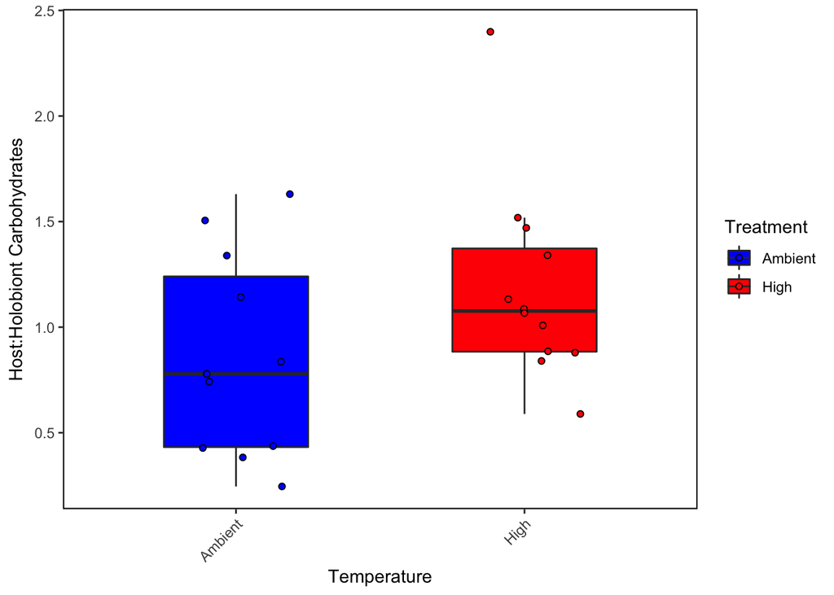

```r
Ratio.Plot.norm <- ratios_norm%>%
  ggplot(aes(x=Treatment, y=ratio, fill=Treatment)) +
  geom_boxplot(width=.5, outlier.shape= NA, position = position_dodge(width = 0.4)) +
  geom_point(pch = 21, position=position_jitterdodge(dodge.width=0.4)) +
   scale_fill_manual(values=c("blue", "red"))+
  xlab("Temperature") + ylab(expression("Host:Holobiont Carbohydrates")) + #Axis titles
  theme_bw() + theme(panel.border = element_rect(color="black", fill=NA, size=0.75), panel.grid.major = element_blank(),
                     panel.grid.minor = element_blank(), axis.line = element_blank()) +
  theme(axis.text.x = element_text(angle = 45, hjust = 1)); Ratio.Plot.norm
```

Test for differences with an anova.

```r
model<-aov(ratio~Treatment, data=ratios_norm)
summary(model)
```

```
##             Df Sum Sq Mean Sq F value Pr(>F)
## Treatment    1  0.603  0.6029   2.685  0.116
## Residuals   21  4.716  0.2246
```

No significant differences in carbohydrate ratios between host and holobiont fractions once normalized to protein.

# **Normalize to cell density**

## Holobiont

Read in cell density values.

```r
cells<-read.csv("Mcap2021/Output/Cells/cells_output.csv")
```

Merge data frames.

```r
cells_data_holo<-Samples%>%
  dplyr::select(Treatment, Fraction, Sample.ID, Resuspension_volume, Carb.mg)%>%
  filter(!Treatment=="Astrangia")%>%
  filter(Fraction=="Holobiont")%>%
  filter(!Sample.ID=="H")%>%
  group_by(Treatment, Fraction, Sample.ID, Resuspension_volume)%>%
  dplyr::summarise(Carb.mg=mean(Carb.mg))%>%
  mutate(Carb.mg.uL=Carb.mg/Resuspension_volume)
```

[output not shown]

```r
cells<-cells%>%
  dplyr::select(Sample.ID, cells.uL)

cells_data_holo<-left_join(cells_data_holo, cells, by="Sample.ID")

cells_data_holo<-cells_data_holo%>%
  mutate(Carb.mg.cell=Carb.mg.uL/cells.uL)%>%
  mutate(Carb.ug.cell=Carb.mg.cell*1000)
```

Plot.

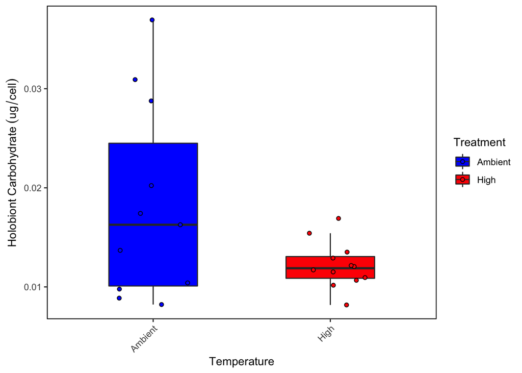

```r
Carb.Plot.cells.holo <- cells_data_holo%>%
  filter(!Sample.ID=="H")%>%
  ggplot(aes(x=Treatment, y=Carb.ug.cell, fill = Treatment)) +
  geom_boxplot(width=.5, outlier.shape= NA, position = position_dodge(width = 0.4)) +
  scale_fill_manual(values=c("blue", "red"))+
  geom_point(pch = 21, position=position_jitterdodge(dodge.width=0.4)) +
  xlab("Temperature") + ylab(expression("Holobiont Carbohydrate " (ug/cell))) + #Axis titles
  theme_bw() + theme(panel.border = element_rect(color="black", fill=NA, size=0.75), panel.grid.major = element_blank(),
                     panel.grid.minor = element_blank(), axis.line = element_blank()) +
  theme(axis.text.x = element_text(angle = 45, hjust = 1)); Carb.Plot.cells.holo
```

Test for differences with an anova.

```r
cells_data_model_holo<-cells_data_holo%>%
  filter(!Sample.ID=="H")

model<-aov(Carb.ug.cell~Treatment, data=cells_data_model_holo)
summary(model)
```

```
##             Df    Sum Sq   Mean Sq F value Pr(>F)
## Treatment    1 0.0002163 2.163e-04   4.404 0.0481 *
## Residuals   21 0.0010313 4.911e-05
## ---
## Signif. codes:  0 '***' 0.001 '**' 0.01 '*' 0.05 '.' 0.1 ' ' 1
```

## Host

Read in cell density values.

```r
cells<-read.csv("Mcap2021/Output/Cells/cells_output.csv")
```

Merge data frames.

```r
cells_data_host<-Samples%>%
  dplyr::select(Treatment, Fraction, Sample.ID, Resuspension_volume, Carb.mg)%>%
  filter(!Treatment=="Astrangia")%>%
  filter(Fraction=="Host")%>%
  filter(!Sample.ID=="H")%>%
  group_by(Treatment, Fraction, Sample.ID, Resuspension_volume)%>%
  dplyr::summarise(Carb.mg=mean(Carb.mg))%>%
  mutate(Carb.mg.uL=Carb.mg/Resuspension_volume)
```

[output not shown]

```r
cells<-cells%>%
  dplyr::select(Sample.ID, cells.uL)

cells_data_host<-left_join(cells_data_host, cells, by="Sample.ID")

cells_data_host<-cells_data_host%>%
  mutate(Carb.mg.cell=Carb.mg.uL/cells.uL)%>%
  mutate(Carb.ug.cell=Carb.mg.cell*1000)
```

Plot.

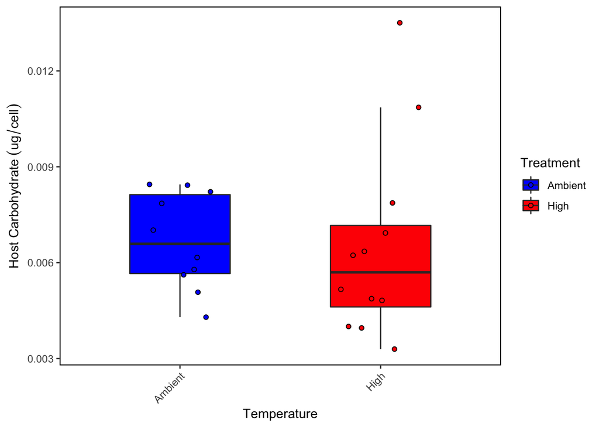

```r
Carb.Plot.cells.host <- cells_data_host%>%
  filter(!Sample.ID=="H")%>%
  filter(Carb.ug.cell<0.02)%>%
  filter(Carb.ug.cell>0.003)%>%
  ggplot(aes(x=Treatment, y=Carb.ug.cell, fill = Treatment)) +
  geom_boxplot(width=.5, outlier.shape= NA, position = position_dodge(width = 0.4)) +
  scale_fill_manual(values=c("blue", "red"))+
  geom_point(pch = 21, position=position_jitterdodge(dodge.width=0.4)) +
  xlab("Temperature") + ylab(expression("Host Carbohydrate " (ug/cell))) + #Axis titles
  theme_bw() + theme(panel.border = element_rect(color="black", fill=NA, size=0.75), panel.grid.major = element_blank(), #
                     panel.grid.minor = element_blank(), axis.line = element_blank()) +
  theme(axis.text.x = element_text(angle = 45, hjust = 1)); Carb.Plot.cells.host
```

Test for differences with an anova.

```r
cells_data_model_host<-cells_data_host%>%
  filter(!Sample.ID=="H")%>%
  filter(Carb.ug.cell<0.02)%>%
  filter(Carb.ug.cell>0.003)

model<-aov(Carb.ug.cell~Treatment, data=cells_data_model_host)
summary(model)
```

[output not shown]

Make a data frame to calculate ratios.

```r
head(cells_data_holo)
```

```
## # A tibble: 6 × 9
## # Groups:   Treatment, Fraction, Sample.ID [6]
##   Treatment Fraction  Sample.ID Resuspension_volume Carb.mg Carb.mg.uL cells.uL
##   <chr>     <chr>     <chr>                   <int>   <dbl>      <dbl>    <dbl>
## 1 Ambient   Holobiont A                         500    8.85    0.0177      875
## 2 Ambient   Holobiont B                         500    2.89    0.00578     422.
## 3 Ambient   Holobiont C                         500    5.37    0.0107      617.
## 4 Ambient   Holobiont D                         500    3.05    0.00609     374.
## 5 Ambient   Holobiont E                         500    1.95    0.00390     439.
## 6 Ambient   Holobiont F                         500    2.67    0.00534     144.
## # … with 2 more variables: Carb.mg.cell <dbl>, Carb.ug.cell <dbl>
```

```r
head(cells_data_host)
```

```
## # A tibble: 6 × 9
## # Groups:   Treatment, Fraction, Sample.ID [6]
##   Treatment Fraction Sample.ID Resuspension_volume Carb.mg Carb.mg.uL cells.uL
##   <chr>     <chr>    <chr>                   <int>   <dbl>      <dbl>    <dbl>
## 1 Ambient   Host     A                         250   0.939    0.00376     875
## 2 Ambient   Host     B                         200   0.711    0.00356     422.
## 3 Ambient   Host     C                         200   0.969    0.00484     617.
## 4 Ambient   Host     D                         150   0.316    0.00210     374.
## 5 Ambient   Host     E                         200   0.446    0.00223     439.
## 6 Ambient   Host     F                         200   0.244    0.00122     144.
## # … with 2 more variables: Carb.mg.cell <dbl>, Carb.ug.cell <dbl>
```

```r
cells_data_holo<-cells_data_holo%>%
  dplyr::select(Treatment, Fraction, Sample.ID, Carb.ug.cell)%>%
  spread(Fraction, Carb.ug.cell)

cells_data_host<-cells_data_host%>%
  dplyr::select(Treatment, Fraction, Sample.ID, Carb.ug.cell)%>%
  spread(Fraction, Carb.ug.cell)

ratios_cells<-left_join(cells_data_holo, cells_data_host)
head(ratios_cells)
```

```
## # A tibble: 6 × 4
## # Groups:   Treatment, Sample.ID [6]
##   Treatment Sample.ID Holobiont    Host
##   <chr>     <chr>         <dbl>   <dbl>
## 1 Ambient   A           0.0202  0.00429
## 2 Ambient   B           0.0137  0.00842
## 3 Ambient   C           0.0174  0.00785
## 4 Ambient   D           0.0163  0.00562
## 5 Ambient   E           0.00887 0.00508
## 6 Ambient   F           0.0369  0.00845
```

```r
ratios_cells<-ratios_cells%>%
  mutate(ratio=Holobiont/Host)
```

Plot.

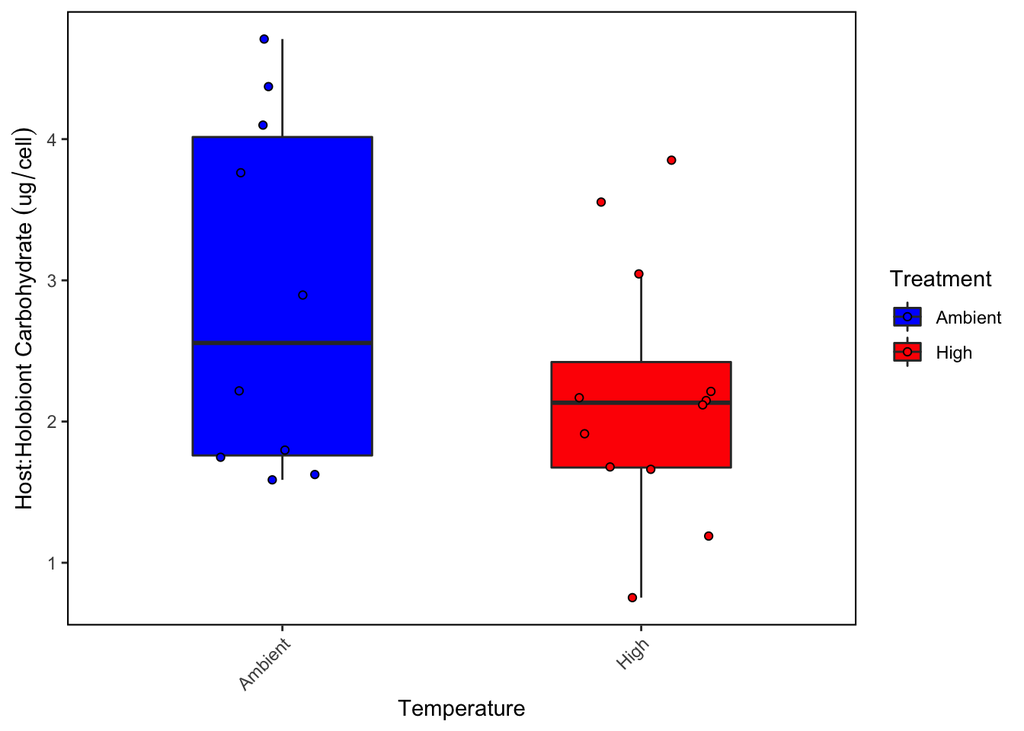

```r
Carb.Plot.cells.ratio <- ratios_cells%>%
  filter(!Sample.ID=="H")%>%
  filter(!Sample.ID=="L")%>%
  ggplot(aes(x=Treatment, y=ratio, fill = Treatment)) +
  geom_boxplot(width=.5, outlier.shape= NA, position = position_dodge(width = 0.4)) +
  scale_fill_manual(values=c("blue", "red"))+
  geom_point(pch = 21, position=position_jitterdodge(dodge.width=0.4)) +
  xlab("Temperature") + ylab(expression("Host:Holobiont Carbohydrate " (ug/cell))) + #Axis titles
  theme_bw() + theme(panel.border = element_rect(color="black", fill=NA, size=0.75), panel.grid.major = element_blank(),
                     panel.grid.minor = element_blank(), axis.line = element_blank()) +
  theme(axis.text.x = element_text(angle = 45, hjust = 1)); Carb.Plot.cells.ratio
```

Test for differences with an anova.

```r
ratios_cells_model<-ratios_cells%>%
  filter(!Sample.ID=="H")%>%
  filter(!Sample.ID=="L")

model<-aov(ratio~Treatment, data=ratios_cells_model)
summary(model)
```

[output not shown]